# Assignment 1 - The tidyverse

RGazzaneo

September 13, 2024 | 11:17:40 | CEST

```r
data <- read.csv("astronauts.csv")
library(ggplot2)
```

## Getting started with the Astronaut Database

The data this week comes from [Mariya Stavnichuk and Tatsuya Corlett](https://data.mendeley.com/datasets/86tsnnbv2w/1).

This [article](https://www.sciencedirect.com/science/article/abs/pii/S2214552420300444) talks about the data set in greater detail.

> This database contains publically available information about all astronauts who participated in space missions before 15 January 2020 collected from NASA, Roscosmos, and fun-made websites. The provided information includes full astronaut name, sex, date of birth, nationality, military status, a title and year of a selection program, and information about each mission completed by a particular astronaut such as a year, ascend and descend shuttle names, mission and extravehicular activity (EVAs) durations.

Credit for preparing the data set: [Georgios Karamanis](https://twitter.com/geokaramanis)

You can use the data set directly by importing the csv file in the repository.

If not noted otherwise, for the following tasks, you will work only with a subset of astronauts based on their **year of birth**. The year span you are assigned depends on your first name:

| Your first name starts with… | Years of birth |
| --- | --- |
| A-I | (1921-1942] |
| J-R | (1943-1964] |
| S-Z | (1965-1983] |

### Task 1 - Descriptives

1. How many unique astronauts were there in the full data set and how many are there in your subset? (*Note that some might have been part of multiple missions.*)

```r
# YOUR CODE HERE

# Unique Astronauts with the full data set
unique_entries_all <- length(unique(data$name))
# Create subset (1943-1964]
subset_1943_1964 <- subset(data, year_of_birth > 1943 & year_of_birth <= 1964)
# Unique Astronauts with the subset
unique_entries_subset <- length(unique(subset_1943_1964$name))
print(paste("Answer:" , unique_entries_subset))
```

```
[1] "Answer: 330"
```

2. What is the overall share of female astronauts in the subset of data you were assigned to?

```r
# YOUR CODE HERE

#Number of female in the filtered subset
number_female <- length(unique(subset_1943_1964[subset_1943_1964$sex == 'female', ]$name))
#Overall Share
female_share <- number_female/unique_entries_subset
print(paste("Answer:" , female_share))
```

```
[1] "Answer: 0.133333333333333"
```

3. How many (both in absolute and relative terms) astronauts were U.S. nationals in your subset?

```r
# YOUR CODE HERE

#absolute number of US astronauts
number_us <- length(unique(subset_1943_1964[subset_1943_1964$nationality == 'U.S.', ]$name))
#relative number of US astronauts
percent_us <- number_us*100/unique_entries_subset
percent_values <- sprintf("%.2f%%", percent_us)
cat(" Answer in absolut terms:" , number_us, "\n", "Answer in relative terms:" , percent_values)
```

```
 Answer in absolut terms: 221
 Answer in relative terms: 66.97%
```

4. Create a new data set `total_hours_df` containing the unique names and the total duration of all missions in hours (`total_hrs_sum`) for each astronaut in the subset. Then, visualize the distribution of that variable using an appropriate plot type.

```r
# YOUR CODE HERE

#creating dataset
total_hours_df <- aggregate(hours_mission ~ name, data = subset_1943_1964, FUN = sum)
#renaming column b
names(total_hours_df)[names(total_hours_df) == "hours_mission"] <- "total_hrs_sum"
print("Check table total_hours_df")
```

```
[1] "Check table total_hours_df"
```

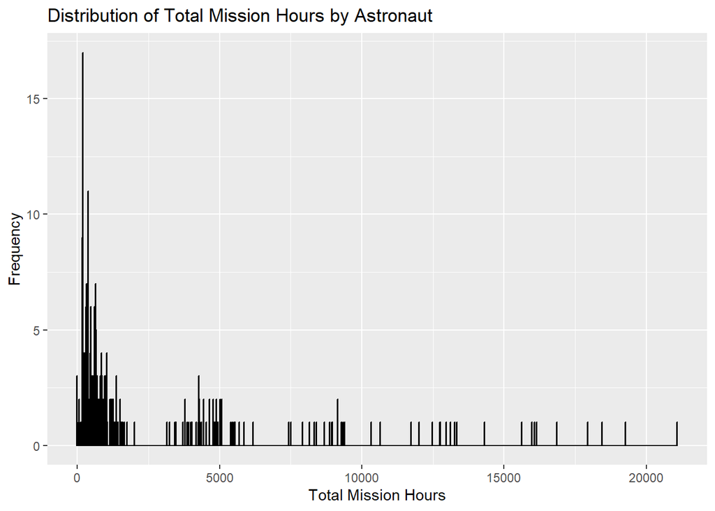

```r
#create Histogram of the distribution
ggplot(total_hours_df, aes(x = total_hrs_sum)) +
  geom_histogram(binwidth = 10, fill = "blue", color = "black") +
  labs(title = "Distribution of Total Mission Hours by Astronaut",
       x = "Total Mission Hours",
       y = "Frequency")
```

5. Who were the top 10 astronauts that went in the most unique missions in your subset? (*Note: There might be ties, so only print the default top 10.*)

```r
# YOUR CODE HERE

#aggregate per number of missions
mission_top10 <- aggregate(hours_mission ~ name, data = subset_1943_1964, FUN = length)
#rename colunm b
names(mission_top10)[2] <- "mission_count"
#order to select top10
mission_top10 <- mission_top10[order(-mission_top10$mission_count), ][1:10, ]
print(mission_top10)
```

```
                       name mission_count
54  Chang-Diaz, Franklin R.             7
257          Ross, Jerry L.             7
39    Brown, Curtis L., Jr.             6
94        Foale, C. Michael             6
167        Krikalev, Sergei             6
186       Malenchenko, Yuri             6
318     Wetherbee, James D.             6
37     Bowersox, Kenneth D.             5
66     Cockrell, Kenneth D.             5
82        Dunbar, Bonnie J.             5
```

6. Generate a table that provides the 5 astronauts with the longest names (in terms of number of characters, ignoring whitespace).

```r
# YOUR CODE HERE

#remove name repetition
name_top5 <- subset_1943_1964[!duplicated(subset_1943_1964$name), ]
#remove whitespace
name_top5$clean_name <- gsub(" ", "", name_top5$name)
#length of each name
name_top5$name_length <- nchar(name_top5$clean_name)
#order to select top5
name_top5 <- name_top5[order(-name_top5$name_length), ][1:5, c("name", "name_length")]
print(name_top5)
```

```
                                   name name_length
432  McAuliffe, Sharon Christa Corrigan          31
876   André-Deshays, Claudie (Haigneré)          31
580    Hughes-Fulford, Millie Elizabeth          30
1082   Stefanyshyn-Piper, Heidemarie M.          30
320    Garneau, Marc Joseph Jean-Pierre          29
```

### Task 2 - Exploring trends in the data

1. Using the full data set, provide a plot that shows the overall share of *civilian* astronauts by the year of mission!

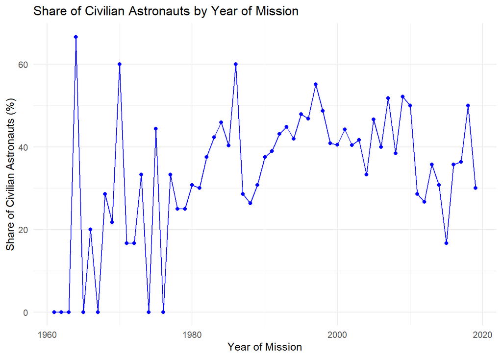

```r
# YOUR CODE HERE

#filtering for civilians
civilians <- data[data$military_civilian == "civilian", ]
#number of civilian and total astronauts per year
total_counts <- aggregate(military_civilian ~ year_of_mission, data = data, FUN = length)
civilian_counts <- aggregate(military_civilian ~ year_of_mission, data = civilians, FUN = length)
#rename columns
names(total_counts)[2] <- "total_astronauts"
names(civilian_counts)[2] <- "civilian_astronauts"
#merge by year_of_mission
merged_counts <- merge(total_counts, civilian_counts, by = "year_of_mission", all.x = TRUE)
merged_counts$civilian_astronauts[is.na(merged_counts$civilian_astronauts)] <- 0
#share of civilian astronauts
merged_counts$civilian_share <- (merged_counts$civilian_astronauts / merged_counts$total_astronauts) * 100

ggplot(merged_counts, aes(x = year_of_mission, y = civilian_share)) +
  geom_line(color = "blue") +
  geom_point(color = "blue") +
  labs(title = "Share of Civilian Astronauts by Year of Mission",
       x = "Year of Mission",
       y = "Share of Civilian Astronauts (%)") +
  theme_minimal()
```

2. Explore another relation of variables in the data set. Your analysis should (i) *use the full data set* and (ii) feature *data from several years*. Also, offer a brief description and interpretation of your findings!

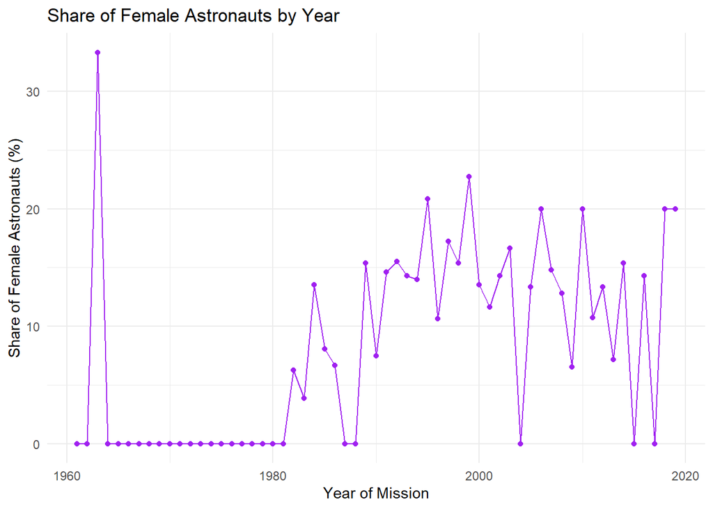

```r
#filtering
females <- data[data$sex == "female", ]
total_counts <- aggregate(sex ~ year_of_mission, data = data, FUN = length)
female_counts <- aggregate(sex ~ year_of_mission, data = females, FUN = length)
names(total_counts)[2] <- "total_astronauts"
names(female_counts)[2] <- "female_astronauts"
# calculating shares
years <- unique(total_counts$year_of_mission)
female_counts$year_of_mission <- as.numeric(as.character(female_counts$year_of_mission))
total_counts$year_of_mission <- as.numeric(as.character(total_counts$year_of_mission))
#populate table
total_counts$female_astronauts <- 0
total_counts$female_astronauts[match(female_counts$year_of_mission, total_counts$year_of_mission)] <- female_counts$female_astronauts
total_counts$female_astronauts[is.na(total_counts$female_astronauts)] <- 0
#calculating share
total_counts$female_share <- (total_counts$female_astronauts / total_counts$total_astronauts) * 100

ggplot(total_counts, aes(x = year_of_mission, y = female_share)) +
  geom_line(color = "purple") +
  geom_point(color = "purple") +
  labs(title = "Share of Female Astronauts by Year",
       x = "Year of Mission",
       y = "Share of Female Astronauts (%)") +
  theme_minimal()
```

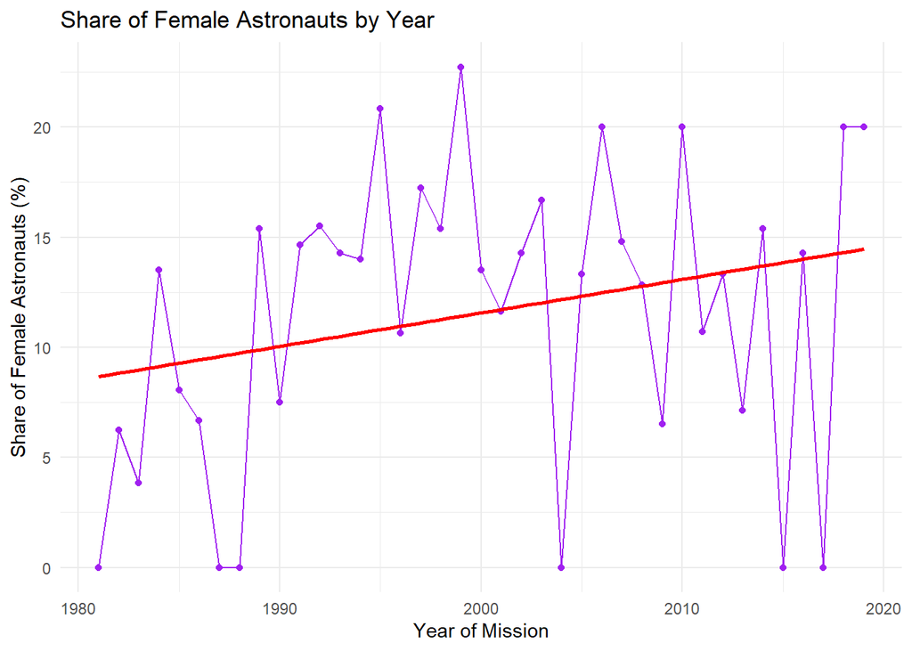

```r
#discarding data before 1980
total_counts2 <- subset(total_counts, year_of_mission > 1980)
#recalculating female share
total_counts2$female_share <- (total_counts2$female_astronauts / total_counts2$total_astronauts) * 100

plot <- ggplot(total_counts2, aes(x = year_of_mission, y = female_share)) +
  geom_line(color = "purple") +
  geom_point(color = "purple") +
  geom_smooth(method = "lm", color = "red", se = FALSE) +
  labs(title = "Share of Female Astronauts by Year",
       x = "Year of Mission",
       y = "Share of Female Astronauts (%)") +
  theme_minimal()
print(plot)
```

Using the full data set, we can see a plot that shows the overall share of female astronauts by the year of mission, after analysis the year of 1963 was considered an outlier and the years before 1981 were discarded in order to trace a trend line for the more relevant years.

By observing the trend line, it is possible to notice that although it has been variations in the share of woman in mission since 1980, the percentage has slightly increased throughout the years.

Therefore we can interpreted that the participation of female astronauts in mission tends to increase, even though still minor (around 20%).